# Assess cancer predisposition gene splicing in PBTA germline cohort

Ryan Corbett

This script compares identifies tumor differential splicing events in patients and cancer predisposition genes harboring a germline P/LP variant.

# Load libraries

```r
suppressPackageStartupMessages({
  library(ggplot2)
  library(tidyverse)
  library(vroom)
  library(circlize)
  library(ggpubr)
  library(ggrepel)
})

# Set up directories
root_dir <- rprojroot::find_root(rprojroot::has_dir(".git"))

data_dir <- file.path(root_dir, "data")
analysis_dir <- file.path(root_dir, "analyses", "two-hits")
input_dir <- file.path(analysis_dir, "input")
results_dir <- file.path(analysis_dir, "results")
plot_dir <- file.path(analysis_dir, "plots")

# If the directory does not exist, create it
if (!dir.exists(results_dir)) {
  dir.create(results_dir, recursive = TRUE)
}

# Call plotting theme
source(file.path(root_dir, "figures", "theme.R"))
```

Set input file paths

```r
plp_file <- file.path(data_dir,
                      "pbta-merged-plp-variants-autogvp-abridged.tsv")

plp_lowVAF_file <- file.path(data_dir,
                             "pbta-merged-plp-variants-autogvp-abridged-lowVAF-cpgs.tsv")

plp_sv_file <- file.path(data_dir,
                         "pbta_germline_svs.tsv")

histologies_file <- file.path(data_dir,
                              "histologies.tsv")

hist_cohort_file <- file.path(root_dir, "analyses",
                              "collapse-tumor-histologies", "results",
                              "germline-primary-plus-tumor-histologies-plot-groups-clin-meta.tsv")

splice_events_file <- file.path(input_dir,
                                "splice_events_germline_pbta_cpgs_only.tsv.gz")

# cpg file
cpg_file <- file.path(root_dir, "analyses", "oncokb-annotation",
                      "input", "cpg.txt")
```

# Load files

```r
opc_hist <- read_tsv(histologies_file)
hist <- read_tsv(hist_cohort_file) %>%
  dplyr::rename(Kids_First_Biospecimen_ID = Kids_First_Biospecimen_ID_tumor) %>%
  left_join(opc_hist %>% dplyr::select(Kids_First_Biospecimen_ID,
                                   match_id)) %>%
  left_join(opc_hist %>% dplyr::filter(experimental_strategy == "RNA-Seq") %>%
              dplyr::rename(Kids_First_Biospecimen_ID_rna = Kids_First_Biospecimen_ID) %>%
              dplyr::select(match_id, Kids_First_Biospecimen_ID_rna))
# Full P/LP results
plp <- read_tsv(plp_file) %>%
  bind_rows(read_tsv(plp_lowVAF_file)) %>%
  dplyr::rename(Hugo_Symbol = gene_symbol_vep) %>%
  dplyr::filter(Kids_First_Biospecimen_ID_normal %in% hist$Kids_First_Biospecimen_ID_normal)
plp_sv <- read_tsv(plp_sv_file) %>%
  dplyr::rename(Hugo_Symbol = Hugo_Symbol_cpg) %>%
  dplyr::filter(Kids_First_Biospecimen_ID_normal %in% hist$Kids_First_Biospecimen_ID_normal)
# CPGs
cpgs <- read_lines(cpg_file)

splice_events <- vroom(splice_events_file) %>%
  dplyr::filter(sample_id %in% hist$Kids_First_Biospecimen_ID_rna,
                geneSymbol %in% c(plp$Hugo_Symbol, plp_sv$Hugo_Symbol),
                splicing_case != "MXE") %>%
  dplyr::mutate(region = case_when(
          splicing_case %in% c("A3SS", "A5SS") ~ glue::glue("{longExonStart_0base}:{longExonEnd}:{shortES}:{shortEE}:{flankingES}:{flankingEE}"),
          splicing_case == "RI" ~ glue::glue("{riExonStart_0base}:{riExonEnd}:{upstreamES}:{upstreamEE}:{downstreamES}:{downstreamEE}"),
          splicing_case == "SE" ~ glue::glue("{exonStart_0base}:{exonEnd}:{upstreamES}:{upstreamEE}:{downstreamES}:{downstreamEE}")
        )) %>%
  dplyr::select(-IncLevel2, -GeneID, -control_id, -chr, -strand, -IJC_SAMPLE_1,
         -IJC_SAMPLE_2, -SJC_SAMPLE_1, -SJC_SAMPLE_2, -IncFormLen,
         -SkipFormLen, -PValue, -FDR, -IncLevelDifference,
         -`1stExonStart_0base`, -`1stExonEnd`, -`2ndExonStart_0base`,
         -`2ndExonEnd`) %>%
  dplyr::rename(Kids_First_Biospecimen_ID_rna = sample_id,
                Hugo_Symbol = geneSymbol)
hist <- hist %>%
  dplyr::filter(Kids_First_Biospecimen_ID_rna %in% splice_events$Kids_First_Biospecimen_ID_rna) %>%
  distinct(match_id, .keep_all = TRUE)
```

Define CPGs with P/LP variants in cohort, and splicing cases to query

```r
cpgs_test <- plp %>%
    filter(Hugo_Symbol %in% cpgs) %>%
  dplyr::select(Hugo_Symbol) %>%
  bind_rows(plp_sv %>% dplyr::select(Hugo_Symbol)) %>%
  pull(Hugo_Symbol) %>%
  unique()

#Define splicing cases
splicing_cases <- c("A3SS", "A5SS", "RI", "SE")
```

Identify splicing event PSI z-scores as follows: 1) Loop through genes with P/LP variants in cohort 2) Loop through patients harboring P/LP variants in gene 3) Loop through splicing cases (SE, RI, etc.) 4) Loop through each splicing region 5) Extract sample PSI and z-score, and calculate mean PSI for rest of histology group and PSI difference (sample - other) 6) Append statistics to data frame

```r
splice_psi_df <- tibble(
  Hugo_Symbol = character(),
  Kids_First_Biospecimen_ID_rna = character(),
  plot_group = character(),
  splicing_case = character(),
  exon_region = character(),
  PSI_sample = numeric(),
  PSI_other_group = numeric(),
  PSI_other_all = numeric(),
  PSI_diff_group = numeric(),
  PSI_diff_all = numeric(),
  sample_PSI_zscore_group = numeric(),
  sample_PSI_zscore_all = numeric()
)
```

```r
plp_rna_df <- plp %>%
  dplyr::filter(Hugo_Symbol %in% cpgs) %>%
  dplyr::select(Kids_First_Biospecimen_ID_normal, Hugo_Symbol, start) %>%
  bind_rows(plp_sv %>%
              dplyr::filter(Hugo_Symbol %in% cpgs) %>%
              dplyr::select(Kids_First_Biospecimen_ID_normal, Hugo_Symbol)) %>%
  left_join(hist %>%
              dplyr::select(Kids_First_Biospecimen_ID_normal,
                                   Kids_First_Biospecimen_ID_rna)) %>%
  dplyr::filter(!is.na(Kids_First_Biospecimen_ID_rna)) %>%
  left_join(splice_events, by = c("Kids_First_Biospecimen_ID_rna", "Hugo_Symbol")) %>%
  distinct(Kids_First_Biospecimen_ID_rna, Hugo_Symbol, splicing_case, region, .keep_all = TRUE) %>%
  dplyr::mutate(region_start = case_when(
    splicing_case == "RI" ~ as.numeric(unlist(lapply(strsplit(region, ":"), function(x) x[4]))),
    splicing_case == "A5SS" ~ as.numeric(unlist(lapply(strsplit(region, ":"), function(x) x[3]))),
    TRUE ~ as.numeric(unlist(lapply(strsplit(region, ":"), function(x) x[1])))
    )) %>%
  dplyr::mutate(region_end = case_when(
    splicing_case == "RI" ~ as.numeric(unlist(lapply(strsplit(region, ":"), function(x) x[6]))),
    splicing_case == "A3SS" ~ as.numeric(unlist(lapply(strsplit(region, ":"), function(x) x[3]))),
    TRUE ~ as.numeric(unlist(lapply(strsplit(region, ":"), function(x) x[2])))
    )) %>%
  dplyr::mutate(start_dist = abs(start - region_start),
                end_dist = abs(start - region_end)) %>%
  transform(min_dist = pmin(start_dist, end_dist)) %>%
  arrange(min_dist) %>%
  distinct(Kids_First_Biospecimen_ID_rna, Hugo_Symbol, splicing_case, .keep_all = TRUE)
splice_events <- splice_events %>%
  dplyr::filter(region %in% plp_rna_df$region)

system.time(

  for (i in 1:nrow(plp_rna_df)){

    id <- plp_rna_df$Kids_First_Biospecimen_ID_rna[i]
    cpg <- plp_rna_df$Hugo_Symbol[i]

    case <- plp_rna_df$splicing_case[i]
    reg <- plp_rna_df$region[i]

    # identify histology group
    group <- hist$plot_group[hist$Kids_First_Biospecimen_ID_rna == id & !is.na(hist$Kids_First_Biospecimen_ID_rna)]

    # extract BS ids of other pts in histology group
    other_group_ids <- hist %>%
      dplyr::filter(Kids_First_Biospecimen_ID_rna != id & plot_group == group) %>%
      pull(Kids_First_Biospecimen_ID_rna)

    other_ids <- hist %>%
      dplyr::filter(Kids_First_Biospecimen_ID_rna != id) %>%
      pull(Kids_First_Biospecimen_ID_rna)

        # calculate PSI z-scores for event
        cpg_splice_events_reg <- splice_events %>%
          dplyr::filter(Hugo_Symbol == cpg & splicing_case == case) %>%
          dplyr::filter(region == reg & Kids_First_Biospecimen_ID_rna %in% c(id, other_group_ids, other_ids)) %>%
          dplyr::mutate(psi_z_score_group = ((IncLevel1 - mean(IncLevel1[Kids_First_Biospecimen_ID_rna %in% c(id, other_group_ids)])) / sd(IncLevel1[Kids_First_Biospecimen_ID_rna %in% c(id, other_group_ids)]))) %>%
          dplyr::mutate(psi_z_score_all = ((IncLevel1 - mean(IncLevel1[Kids_First_Biospecimen_ID_rna %in% c(id, other_ids)])) / sd(IncLevel1[Kids_First_Biospecimen_ID_rna %in% c(id, other_ids)])))

        # If PSI exists for sample, calculate stats
        if (length(cpg_splice_events_reg$IncLevel1[cpg_splice_events_reg$Kids_First_Biospecimen_ID_rna == id]) > 0){

          sample_psi <- cpg_splice_events_reg$IncLevel1[cpg_splice_events_reg$Kids_First_Biospecimen_ID_rna == id]
          # Get mean PSI for all other pts in group
          mean_psi_group <- round(mean(cpg_splice_events_reg$IncLevel1[cpg_splice_events_reg$Kids_First_Biospecimen_ID_rna %in% other_group_ids]), 3)

          mean_psi_all <- round(mean(cpg_splice_events_reg$IncLevel1[cpg_splice_events_reg$Kids_First_Biospecimen_ID_rna %in% other_ids]), 3)

          mean_psi_diff_group <- round(sample_psi - mean_psi_group, 3)

          mean_psi_diff_all <- round(sample_psi - mean_psi_all, 3)

          sample_psi_zscore_group <- round(cpg_splice_events_reg$psi_z_score_group[cpg_splice_events_reg$Kids_First_Biospecimen_ID_rna == id], 3)

          sample_psi_zscore_all <- round(cpg_splice_events_reg$psi_z_score_all[cpg_splice_events_reg$Kids_First_Biospecimen_ID_rna == id], 3)

          # Create df row to append to `splice_psi_df`
          df <- tibble(
            Hugo_Symbol = cpg,
            Kids_First_Biospecimen_ID_rna = id,
            plot_group = group,
            splicing_case = case,
            exon_region = reg,
            PSI_sample = sample_psi,
            PSI_other_group = mean_psi_group,
            PSI_other_all = mean_psi_all,
            PSI_diff_group = mean_psi_diff_group,
            PSI_diff_all = mean_psi_diff_all,
            sample_PSI_zscore_group = sample_psi_zscore_group,
            sample_PSI_zscore_all = sample_psi_zscore_all
          )

          # append results to `splice_psi_df`
          splice_psi_df <- splice_psi_df %>%
            bind_rows(df)

        }

  }

)
```

```
   user  system elapsed
 42.490   0.045  42.512
```

Add normal BS ID and variant distance to splice region start/end, and plot PSI difference against variant distaince

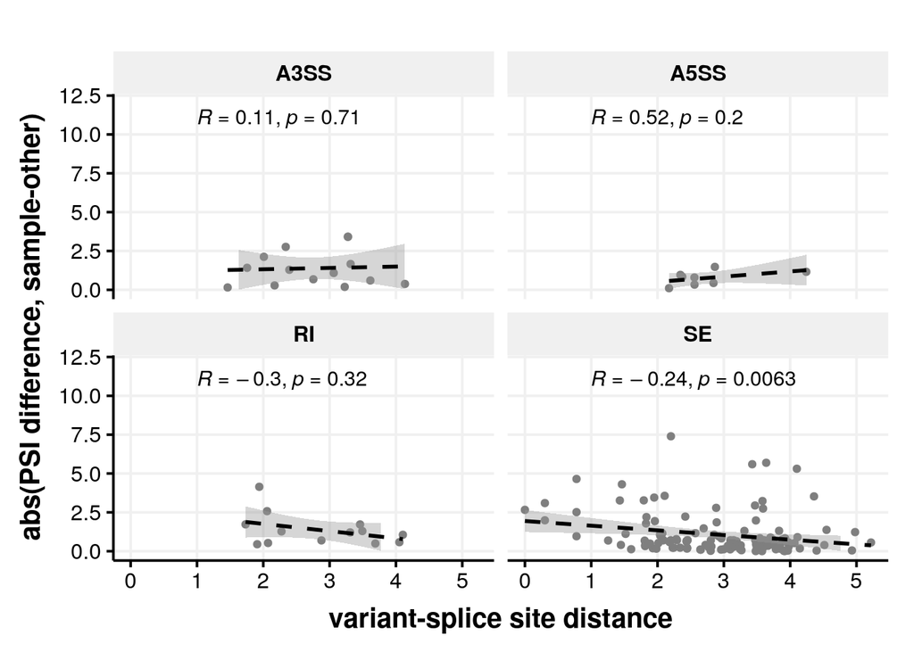

```r
splice_psi_df <- splice_psi_df %>%
  dplyr::mutate(sample_PSI_zscore = case_when(
    !is.na(sample_PSI_zscore_group) ~ sample_PSI_zscore_group,
    !is.na(sample_PSI_zscore_all) ~ sample_PSI_zscore_all
  )) %>%
  left_join(hist[,c("Kids_First_Biospecimen_ID_rna", "Kids_First_Biospecimen_ID_normal")])
snv_splice_psi_df <- splice_psi_df %>%
  left_join(plp[,c("Kids_First_Biospecimen_ID_normal", "Hugo_Symbol", "chr", "start", "ref", "alt", "variant_classification_vep")]) %>%
  dplyr::filter(!is.na(start)) %>%
  dplyr::mutate(region_start = as.numeric(unlist(lapply(strsplit(exon_region, ":"), function(x) x[[1]]))),
                region_end = as.numeric(unlist(lapply(strsplit(exon_region, ":"), function(x) x[[2]])))) %>%
  dplyr::mutate(start_dist = start - region_start,
                end_dist = start - region_end)
# plot PSI diff against variant distance
snv_splice_psi_df %>%
  dplyr::mutate(PSI_zscore = case_when(
    !is.na(sample_PSI_zscore_group) ~ sample_PSI_zscore_group,
    !is.na(sample_PSI_zscore_all) ~ sample_PSI_zscore_all
  )) %>%
  transform(min_dist = pmin(start_dist, end_dist)) %>%
  arrange(abs(min_dist)) %>%
  distinct(chr, start, ref, alt, .keep_all = TRUE) %>%

  ggplot(aes(x = log10(abs(min_dist) + 1), y = abs(PSI_zscore))) +
  geom_point(colour = "gray50") +
  stat_smooth(method = "lm",
              formula = y ~ x,
              geom = "smooth",
              colour = "black",
              linetype="dashed") +
  ylim(c(0, 12)) +
  labs(x = "variant-splice site distance",
       y = "abs(PSI difference, sample-other)") +
  stat_cor(method = "spearman", label.x = 1,
           label.y = 11, size = 4) +
  facet_wrap(~splicing_case, nrow = 2) +
  theme_Publication()
```

```r
ggsave(file.path(plot_dir, "PSI-diff-by-variant-dist.pdf"),
       width = 9, height = 6)
```

Format data frame and write to output

```r
snv_splice_psi_df <- snv_splice_psi_df %>%
  dplyr::rename(plp_variant_position = start) %>%
  dplyr::select(Kids_First_Biospecimen_ID_normal, Kids_First_Biospecimen_ID_rna,
                plot_group, Hugo_Symbol, chr, splicing_case, exon_region,
                PSI_sample, PSI_other_group, PSI_other_all,
                PSI_diff_group, PSI_diff_all,
                sample_PSI_zscore_group, sample_PSI_zscore_all, sample_PSI_zscore,
                plp_variant_position, ref, alt, region_start, region_end,
                variant_classification_vep,
                start_dist, end_dist)

write_tsv(snv_splice_psi_df,
          file.path(results_dir, "splicing_events_plp_variants.tsv"))
```

Identify candidate variants associated with differential splicing. These are defined as P/LP variants within 250bp of splice region, where associated splice region has |sample PSI z-score| > 2

```r
expr <- read_tsv(file.path(results_dir, "pbta-germline-gene-expr-zscores.tsv"),
                 show_col_types = FALSE)

plp_splice_candidates <- snv_splice_psi_df %>%
  dplyr::filter(abs(round(sample_PSI_zscore, 1)) >= 2 & (abs(start_dist) < 250 | abs(end_dist) < 250)) %>%
  # order by z-score
  dplyr::arrange(-abs(sample_PSI_zscore)) %>%
  # retain only one splice event per splice region
  distinct(Kids_First_Biospecimen_ID_normal, Hugo_Symbol, region_start, .keep_all = T) %>%
  dplyr::arrange(Hugo_Symbol) %>%
  left_join(hist[,c("Kids_First_Biospecimen_ID_normal", "molecular_subtype")]) %>%
  left_join(expr %>% dplyr::select(Kids_First_Biospecimen_ID_rna,
                                   Hugo_Symbol, expr_zscore))
write_tsv(plp_splice_candidates,
          file.path(results_dir, "candidate_plp_associated_splice_events.tsv"))
```

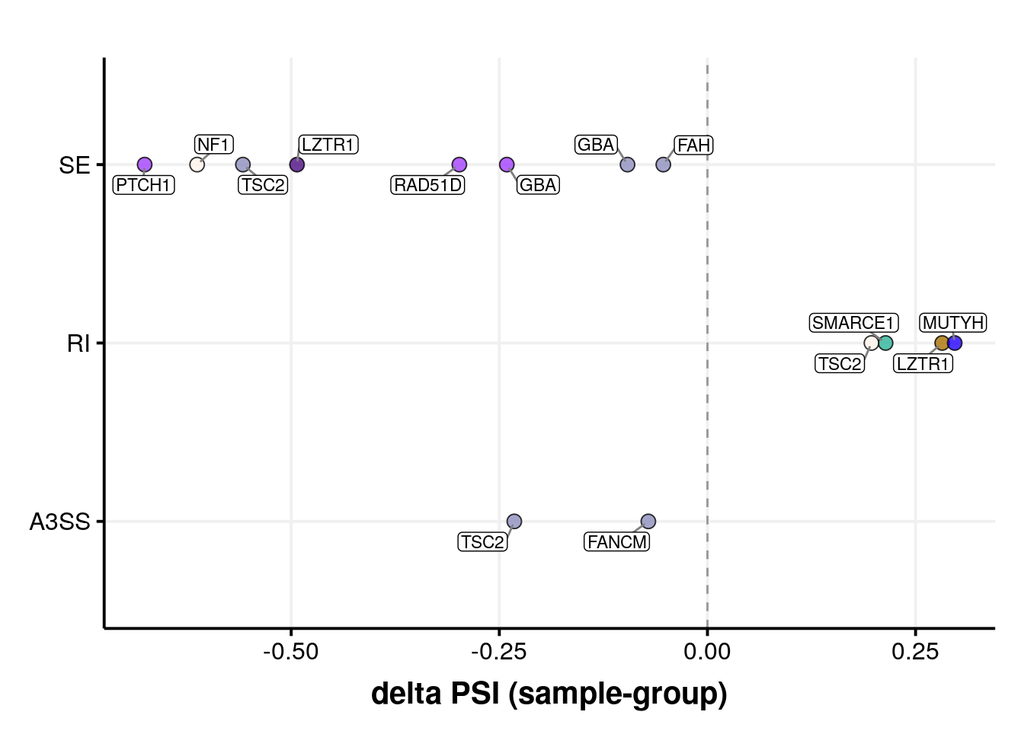

```r
plot_group_palette <- unique(hist$plot_group_hex)
names(plot_group_palette) <- unique(hist$plot_group)

plp_splice_candidates %>%
  dplyr::filter(abs(PSI_diff_group) > 0.05) %>%
  left_join(hist %>% distinct(plot_group, .keep_all = TRUE) %>%
              dplyr::select(plot_group, plot_group_hex)) %>%

  ggplot(aes(x = PSI_diff_group, y = splicing_case,
             label = Hugo_Symbol)) +
  geom_jitter(aes(fill = plot_group),
              shape = 21, width = 0,
              height = 0,
              size = 3, alpha = 0.8,
              show.legend = FALSE) +
  geom_vline(xintercept = 0, linetype = "dashed", color = "gray60") +
  geom_label_repel(aes(label = Hugo_Symbol),
                  size = 3,
                  box.padding   = 0.3,
                  label.padding = 0.1,
                  point.padding = 0.25,
                  segment.color = 'grey50',
                  min.segment.length = 0.1,
                  max.overlaps = 14) +
  scale_fill_manual(values = plot_group_palette,
                     breaks = sort(names(plot_group_palette))) +
  labs(y = NULL, x = "delta PSI (sample-group)") +
  theme_Publication()
```

```r
ggsave(file.path(plot_dir, "germline_plp_alternative_splicing_diff_plot.pdf"),
       width = 4.5, height = 3)
```

Determine if splice region variants exhibit differential proximal exon skipping relative to non-splice region variants

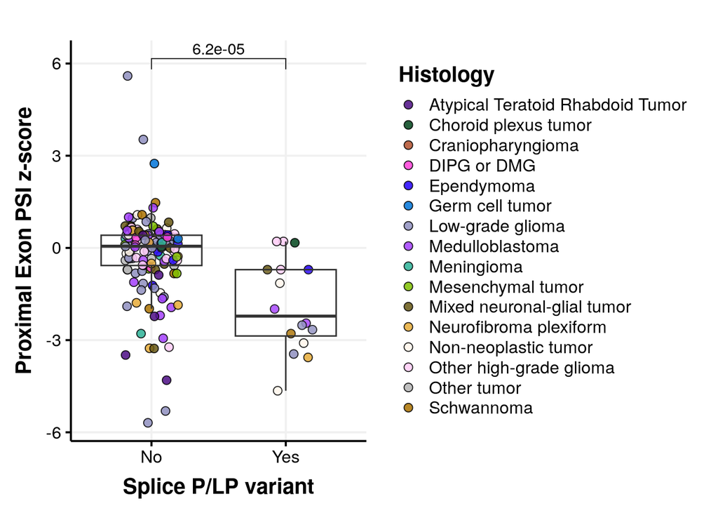

```r
proximal_se <- snv_splice_psi_df %>%
  dplyr::filter(splicing_case == "SE") %>%
  dplyr::mutate(min_dist = pmin(abs(start_dist), abs(end_dist))) %>%
  dplyr::mutate(is_splice_variant = case_when(
    grepl("splic", variant_classification_vep) ~ "Yes",
    !grepl("splic", variant_classification_vep) ~ "No",
  )) %>%
  arrange(abs(min_dist)) %>%
  distinct(Kids_First_Biospecimen_ID_normal, Hugo_Symbol, .keep_all = T) %>%
  dplyr::filter(is_splice_variant != "Yes" | (is_splice_variant == "Yes" & min_dist <= 10)) %>%
  left_join(hist %>%
              dplyr::select(plot_group, plot_group_hex) %>%
              distinct(plot_group, plot_group_hex))
plot_group_palette <- proximal_se$plot_group_hex
names(plot_group_palette) <- proximal_se$plot_group

proximal_se %>%
  ggplot(aes(x = is_splice_variant, y = sample_PSI_zscore)) +
  geom_jitter(aes(fill = plot_group), shape = 21, width = 0.2, size = 2.5, alpha = 0.85) +
  geom_boxplot(alpha = 0.05, outlier.shape = NA) +
  stat_compare_means(method = "wilcox",
                     comparisons = list(c("Yes", "No")),
                     method.args = list(alternative = "two.sided")) +
  labs(x = "Splice P/LP variant", y = "Proximal Exon PSI z-score", fill = "Histology") +
   scale_fill_manual(values = plot_group_palette,
                      breaks = sort(names(plot_group_palette))) +
  theme_Publication()
```

```r
ggsave(file.path(plot_dir,
       "skipped-exon-psi-splice-plp-vs-nonsplice.pdf"),
       width = 7, height = 4)
```